# Практическая работа 1. Простейшие методы регрессии

#### Точки двумерного пространства вида (x, x<sup>2</sup>+ε), где x - нормально распределённые случайные числа со средним 0 и среднеквадратическим отклонением 2, ε - нормально распределённые случайные числа со средним 0 и среднеквадратическим отклонением 0.1 (вариант 9)

#### 1) Линейная регрессия или полиномиальная регрессия (по выбору студента) 2) Сплайновая интерполяция кубическими сплайнами

### Задание 2

#### Программно сгенерировать эти данные, вывести их в виде графика (диаграммы разброса). Количество прецедентов должно задаваться одной из переменных программы, чтобы допустить лёгкое изменение в процессе тестирования. Регрессионные модели должны предсказывать значения последней из координат точек по остальным.

```python
import numpy as np
import sklearn.linear_model
import matplotlib.pyplot as plt
from sklearn.linear_model import LinearRegression
from sklearn.preprocessing import PolynomialFeatures
from sklearn.pipeline import make_pipeline
from scipy.interpolate import interp1d

def generate_samples(NumSamples = 100):
    v = np.random.normal(loc=0, scale=2, size=(NumSamples, 1))
    epsilon = np.random.normal(loc=0, scale=0.1, size=(NumSamples, 1))
    res = np.power(v, 2) + epsilon
    return (v, res)

def draw_samples(v, res):
    fig = plt.figure()
    ax = fig.add_subplot(111)
    ax.scatter(v, res, label='samples')
    ax.set_xlabel('x')
    ax.set_ylabel('x^2 + ε')
    plt.show()
```

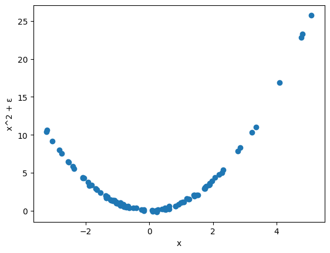

```python
v, res = generate_samples()
draw_samples(v, res)
```

### Задание 3

#### Следует обработать выборку каждым из методов по отдельности и сравнить точности полученных регрессионных моделей (среднеквадратические значения ошибок на использованных выборках). Значения настроечных коэффициентов, если они требуются, следует выбрать самостоятельно; нулевые значения этих коэффициентов не допускаются.

```python
def calculate_regression_by_standard_method(v, res):

    # Полиномиальная регрессия (степень полинома = 3)
    model_poly = make_pipeline(PolynomialFeatures(degree=2), LinearRegression())
    model_poly.fit(v, res)
    prediction_poly = model_poly.predict(v)
    mse_poly = np.mean((res - prediction_poly)**2)
    print("Полиномиальная регрессия (степень 2): MSE =", mse_poly)

    # Кубическая сплайновая интерполяция
    model_spline = interp1d(v.squeeze(), res.squeeze(), kind='cubic')
    prediction_spline = np.array([model_spline(v.squeeze())]).T
    #prediction_spline = model_spline(v.squeeze())
    mse_spline = np.mean((res - prediction_spline)**2)
    print("Кубическая сплайновая интерполяция: MSE =", mse_spline)

    return prediction_poly, prediction_spline


def draw_samples_and_prediction(v, res, prediction):
    fig = plt.figure()
    ax = fig.add_subplot(111)
    ax.scatter(v, res, label='samples', marker='o')
    ax.scatter(v, prediction, label='prediction', marker='^')
    ax.set_xlabel('x')
    ax.set_ylabel('x^2 + ε')
    plt.show()
```

```python
prediction_poly, prediction_spline = calculate_regression_by_standard_method(v, res)
```

```
Полиномиальная регрессия (степень 2): MSE = 0.013061919310653354
Кубическая сплайновая интерполяция: MSE = 3.1856879432482183e-31
```

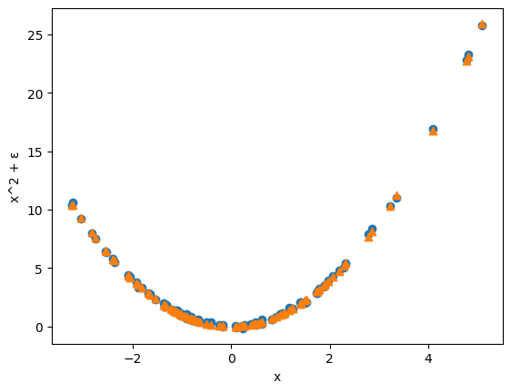

```python
draw_samples_and_prediction(v, res, prediction_poly)
```

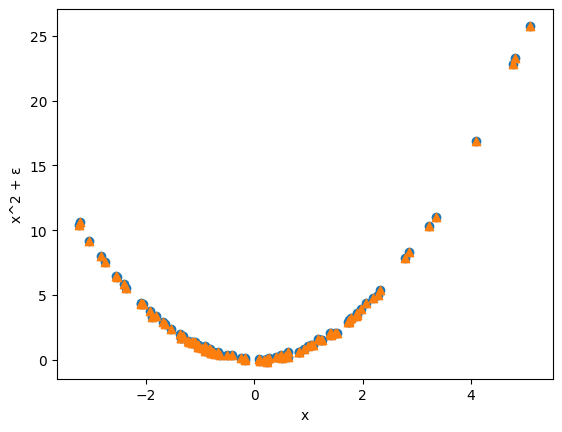

```python
draw_samples_and_prediction(v, res, prediction_spline)
```